# video_4

veronica_barraza

2022-11-07

## Métodos de clasificación

### Clasificacion Supervisada

Entre las aplicaciones más importantes de los datos obtenidos de imágenes satelitales es la generación de mapas de cobertura y uso de suelo, las cuales pueden ser obtenidos a partir de técnicas de clasificacion de imágenes. Las técnicas de clasificación de imagénes se basan en agrupar pixeles que poseen regiones del espectro similares y que pueden asociarse con diferentes clases de coberturas del suelo. En el caso particular de la clasificación supervisada, utiliza datos de entrenamiento que son variables predictoras medidas en cada unidad de muestreo, y asigna clases previas al muestreo. En siguiente diagrama muestra los pasos a realizar en una clasificación supervisada:

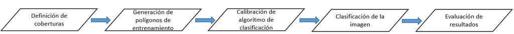

Diagrama_flujo

Los algoritmos de clasificación supervisada varían en la forma en que identifican y describen las regiones en el espacio espectral.

Algunos pueden manejar clases definidas que se superponen entre sí, y otros generan límites firmes entre clases, entre los algoritmos más utilizados se encuentran : Random Forest, maxima verosimilitud, mínima distancia, paralelepipedos.

Machine learning ofrece la posibilidad de una clasificación eficaz y eficiente de imágenes satelites,entre los algoritmos más conocidos se encuentran árboles de decisiones, random forest, redes neuronales. Algunas de sus ventajas:

Capacidad de manejar datos de alta dimensionalidad.

Mapear clases con características muy complejas.

En este tutorial utilizaremos el algoritmo random forest para realizar una clasificación supervisada. R studio presenta diferentes paquetes como: